# Week 6 Lecture

### Exmaple: Basic Scatter Plot

- `s`: Sets the size of the `markers`.
- `c`: Sets the color of the `markers`.
  - [Colors in Matplotlib](https://matplotlib.org/stable/users/explain/colors/colors.html)

```python
# Sample data
x = [5, 7, 8, 7, 2, 17, 2, 9]
y = [99, 86, 87, 88, 100, 86, 103, 87]
size = [100,100,160,200,60,40,60,80]
colors = [1,2,3,4,5,6,7,8]

# Create a scatter plot
plt.scatter(x, y, c=colors, marker='o', s=size)

# Customize the plot
plt.title("Scatter Plot")      # Set title
plt.xlabel("X-axis")           # Label for x-axis
plt.ylabel("Y-axis")           # Label for y-axis
plt.show()
```

# Sample data x = [5, 7, 8, 7, 2, 17, 2, 9] y = [99, 86, 87, 88, 100, 86, 103, 87] size = [100,100,160,200,60,40,60,80] colors = [1,2,3,4,5,6,7,8] # Create a scatter plot plt.scatter(x, y, c=colors, marker='o', s=size) # Customize the plot plt.title("Scatter Plot") # Set title plt.xlabel("X-axis") # Label for x-axis plt.ylabel("Y-axis") # Label for y-axis plt.show()

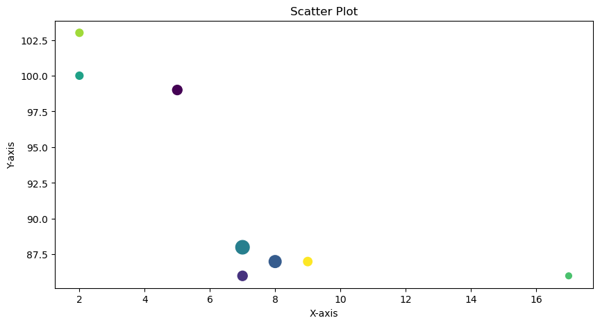

### Example: Basic Histogram

- `bins`: Specifies the number of `bins` for the histogram.
- `edgecolor`: Defines the `color` of the `bin edges`.

```python
# Sample data
data = [1, 2, 2, 2, 3, 3, 4, 4, 5, 5, 6, 7]

# Create a histogram
plt.hist(data, bins=7, color='g', edgecolor='black')

# Customize the plot
plt.title("Histogram Plot")
plt.xlabel("Value")
plt.ylabel("Frequency")
plt.show()
```

# Sample data data = [1, 2, 2, 2, 3, 3, 4, 4, 5, 5, 6, 7] # Create a histogram plt.hist(data, bins=7, color='g', edgecolor='black') # Customize the plot plt.title("Histogram Plot") plt.xlabel("Value") plt.ylabel("Frequency") plt.show()

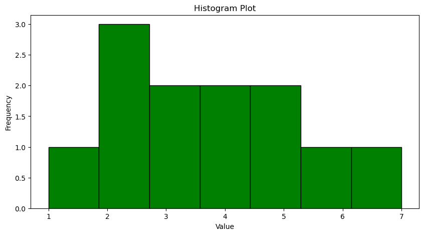

### Example: Basic Bar Plot

```python
# Sample data
categories = ['A', 'B', 'C', 'D', 'E']
values = [5, 7, 3, 8, 6]

# Define colors for each category
colors = ['red', 'green', 'blue', 'orange', 'purple']

# Create a bar plot with different colors for each category
plt.bar(categories, values, color=colors)
plt.title("Basic Bar Plot with Custom Colors")
plt.show()
```

# Sample data categories = ['A', 'B', 'C', 'D', 'E'] values = [5, 7, 3, 8, 6] # Define colors for each category colors = ['red', 'green', 'blue', 'orange', 'purple'] # Create a bar plot with different colors for each category plt.bar(categories, values, color=colors) plt.title("Basic Bar Plot with Custom Colors") plt.show()

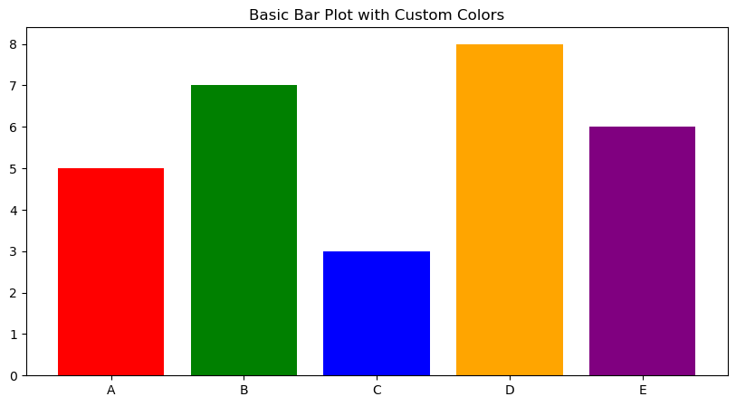

### Example: Horizontal bar chart

- `plt.barh(y, width, color)`:
  - `y`: Labels for the bars (y-axis).
  - `width`: The length of each bar (values).
  - `color`: Specifies the color for each bar.
- `sorted(iterable, key, reverse)`:
  - `iterable`: The data to be sorted.
  - `key`: Specifies the function used to extract a comparison key from each element (optional).
  - `reverse`: Whether to sort in descending order (default is ascending).
- `plt.text(x, y, s, va, fontweight)`:
  - `x`: The x-coordinate where the text will appear.
  - `y`: The y-coordinate where the text will appear.
  - `s`: The string to display (in this case, the value of the bar).
  - `va`: Vertical alignment of the text.
  - `fontweight`: Sets the weight of the text (e.g., 'bold').

```python
categories = ['A', 'B', 'C', 'D', 'E']
values = [5, 7, 3, 8, 6]

# Define colors for each category
colors = ['red', 'green', 'blue', 'orange', 'purple']

# Sort the categories and values based on the values
sorted_data = sorted(zip(values, categories, colors))
print(sorted_data)

values_sorted, categories_sorted, colors_sorted = zip(*sorted_data)

print(values_sorted)
print(categories_sorted)
print(colors_sorted)
```

categories = ['A', 'B', 'C', 'D', 'E'] values = [5, 7, 3, 8, 6] # Define colors for each category colors = ['red', 'green', 'blue', 'orange', 'purple'] # Sort the categories and values based on the values sorted_data = sorted(zip(values, categories, colors)) print(sorted_data) values_sorted, categories_sorted, colors_sorted = zip(*sorted_data) print(values_sorted) print(categories_sorted) print(colors_sorted)

```
[(3, 'C', 'blue'), (5, 'A', 'red'), (6, 'E', 'purple'), (7, 'B', 'green'), (8, 'D', 'orange')]
(3, 5, 6, 7, 8)
('C', 'A', 'E', 'B', 'D')
('blue', 'red', 'purple', 'green', 'orange')
```

```python
demo = [3,2,5,6,4,8]
for i, value in enumerate(demo):
    print(str(i) + ' ' + str(value))
```

demo = [3,2,5,6,4,8] for i, value in enumerate(demo): print(str(i) + ' ' + str(value))

```
0 3
1 2
2 5
3 6
4 4
5 8
```

```python
# Sample data
categories = ['A', 'B', 'C', 'D', 'E']
values = [5, 7, 3, 8, 6]

# Define colors for each category
colors = ['red', 'green', 'blue', 'orange', 'purple']

# Sort the categories and values based on the values
sorted_data = sorted(zip(values, categories, colors))

values_sorted, categories_sorted, colors_sorted = zip(*sorted_data)

# Create a horizontal bar plot with sorted data
plt.barh(y = categories_sorted, width = values_sorted, color=colors_sorted)
plt.title("Horizontal Bar Plot (Sorted by Value)")

# Add annotation (text) on top of each bar
for i, value in enumerate(values_sorted):
    plt.text(x = value+0.2, y = i, s = str(value), va='center', fontweight='bold')

plt.show()
```

# Sample data categories = ['A', 'B', 'C', 'D', 'E'] values = [5, 7, 3, 8, 6] # Define colors for each category colors = ['red', 'green', 'blue', 'orange', 'purple'] # Sort the categories and values based on the values sorted_data = sorted(zip(values, categories, colors)) values_sorted, categories_sorted, colors_sorted = zip(*sorted_data) # Create a horizontal bar plot with sorted data plt.barh(y = categories_sorted, width = values_sorted, color=colors_sorted) plt.title("Horizontal Bar Plot (Sorted by Value)") # Add annotation (text) on top of each bar for i, value in enumerate(values_sorted): plt.text(x = value+0.2, y = i, s = str(value), va='center', fontweight='bold') plt.show()

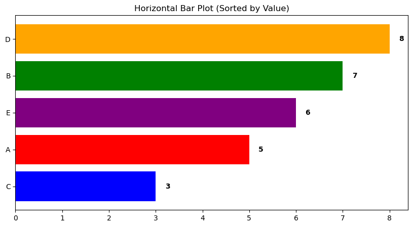

### Example: Basic Pie Chart

- `labels`: Defines the labels for each slice of the pie.
- `autopct`: Displays the percentage value on each slice.
- `startangle`: Sets the starting angle for the first slice.

```python
# Sample data
labels = ['A', 'B', 'C', 'D']
sizes = [20, 30, 25, 25]
colors = ['gold', 'yellowgreen', 'lightcoral', 'lightskyblue']

# Create a pie chart
plt.pie(x = sizes, labels=labels, colors=colors, autopct='%1.4f%%', startangle=180)

# Customize the plot
plt.title("Pie Chart Example")
plt.axis('equal')  # Ensures the pie is drawn as a circle
plt.show()
```

# Sample data labels = ['A', 'B', 'C', 'D'] sizes = [20, 30, 25, 25] colors = ['gold', 'yellowgreen', 'lightcoral', 'lightskyblue'] # Create a pie chart plt.pie(x = sizes, labels=labels, colors=colors, autopct='%1.4f%%', startangle=180) # Customize the plot plt.title("Pie Chart Example") plt.axis('equal') # Ensures the pie is drawn as a circle plt.show()

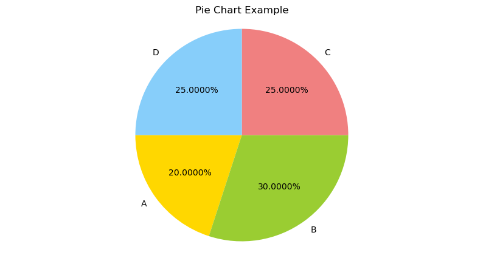

### Example: Basic Box Plot

- `patch_artist`: If `True`, the boxes are drawn with a fill color.

```python
# Sample data
data = [[1, 2, 5, 6, 8], [2, 3, 4, 7, 9], [3, 5, 6, 8, 10]]

# Create a box plot
plt.boxplot(data, patch_artist=True)

# Customize the plot
plt.title("Box Plot")
plt.xlabel("Dataset")
plt.ylabel("Values")
plt.show()
```

# Sample data data = [[1, 2, 5, 6, 8], [2, 3, 4, 7, 9], [3, 5, 6, 8, 10]] # Create a box plot plt.boxplot(data, patch_artist=True) # Customize the plot plt.title("Box Plot") plt.xlabel("Dataset") plt.ylabel("Values") plt.show()

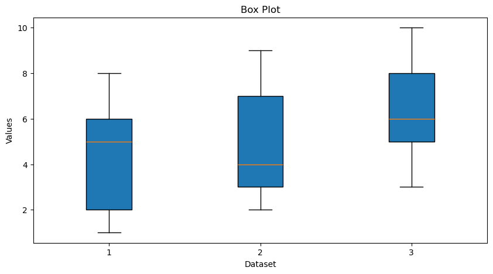

### Example: Basic Subplots

`Subplots` allow multiple plots in one figure for better comparison.

```python
# Sample data
data = [1, 1, 2, 2, 2, 3, 4, 4, 5, 6, 6, 6, 7, 8, 9]

# Create subplots
fig, (ax1, ax2) = plt.subplots(2, 1)

# First subplot - Line plot
ax1.plot(data)
ax1.set_title('Line Plot')

# Second subplot - Bar plot
ax2.hist(data, bins=6)
ax2.set_title('Histogram')

# Show both plots
plt.tight_layout()
plt.show()
```

# Sample data data = [1, 1, 2, 2, 2, 3, 4, 4, 5, 6, 6, 6, 7, 8, 9] # Create subplots fig, (ax1, ax2) = plt.subplots(2, 1) # First subplot - Line plot ax1.plot(data) ax1.set_title('Line Plot') # Second subplot - Bar plot ax2.hist(data, bins=6) ax2.set_title('Histogram') # Show both plots plt.tight_layout() plt.show()

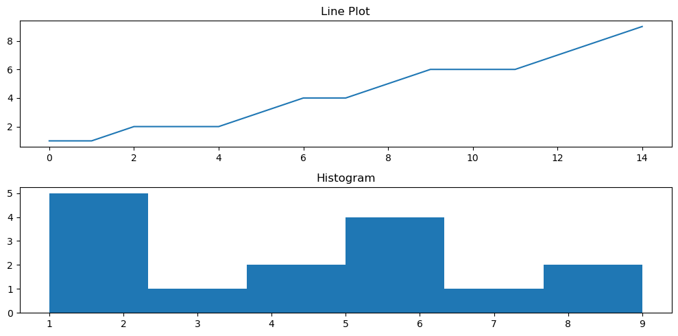

### Saving Your Plots

You can save your visualizations in various formats, such as `PNG`, `JPG`, `PDF`, and `SVG`:

```python
# Sample data
categories = ['A', 'B', 'C', 'D', 'E']
values = [5, 7, 3, 8, 6]

# Define colors for each category
colors = ['red', 'green', 'blue', 'orange', 'purple']

# Create a basic bar plot
plt.bar(categories, values,color=colors)
plt.title("Basic Bar Plot")

plt.savefig('./output/plot.png')
```

# Sample data categories = ['A', 'B', 'C', 'D', 'E'] values = [5, 7, 3, 8, 6] # Define colors for each category colors = ['red', 'green', 'blue', 'orange', 'purple'] # Create a basic bar plot plt.bar(categories, values,color=colors) plt.title("Basic Bar Plot") plt.savefig('./output/plot.png')

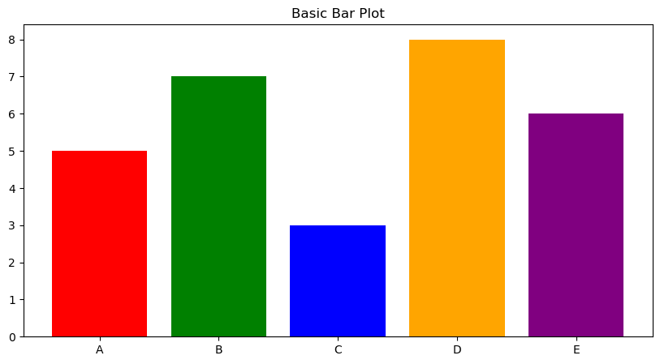

### Additional Learning Resources:

- **Matplotlib Documentation**: [Official Documentation](https://matplotlib.org/stable/index.html)
- **Matplotlib Tutorials**: [Matplotlib Tutorials on Real Python](https://realpython.com/python-matplotlib-guide/)

## Hands-On

In this tutorial, we'll use **Worcester Police Use of Force Incidents (July 2024)** to solve various problems using techiques in `matplotlib`.

Key Questions and Visualizations:

- What is the `time trend` of incidents over the month of July?
  - **Visualization**: Line plot to observe the trend over time.
- What is the `percentage distribution` of incidents involving injuries?
  - **Visualization**: Pie chart to analyze the proportion of incidents resulting in injury vs. no injury.
- Which techniques were `most frequently` used in incidents?
  - **Visualization**: Bar plot to visualize the frequency of different use-of-force techniques.
- What are the **top locations** for incidents?
  - **Visualization**: Horizontal bar plot to analyze location frequency.

### Load data

```python
data = pd.read_csv('F:/Clark_Universiy/Clark_Teaching/Git_Repo/ssj-302/docs/Lectures/data/Worcester_Police_Use_of_Force_Incidents_(July_2024).csv')
data.head(3)
```

data = pd.read_csv('F:/Clark_Universiy/Clark_Teaching/Git_Repo/ssj-302/docs/Lectures/data/Worcester_Police_Use_of_Force_Incidents_(July_2024).csv') data.head(3)

|  | Incident_No | Date___Time | Location | Officer | Narr | Implement | Injury | Supervisor | Notified | ObjectId |
| --- | --- | --- | --- | --- | --- | --- | --- | --- | --- | --- |
| 0 | 2024000078279 | 7/29/24 1:09 PM | 9 LINCOLN SQ Worcester, MA | Daniel Adjei | 1 | R. Empty Hand Compliance Techniques / Level 3 | Visible Injury | Neil F O'Connor | 7/29/24 4:27 PM | 1 |
| 1 | 2024000078796 | 7/30/24 4:38 PM | 6 SHANNON ST Apt #: 2 Worcester, MA | Rachel E Frisch | 3 | R. Empty Hand Compliance Techniques / Level 3 | _None | Michael A Cappabianca Jr | 7/30/24 6:57 PM | 2 |
| 2 | 2024000078796 | 7/30/24 4:38 PM | 6 SHANNON ST Apt #: 2 Worcester, MA | Michael Genese | 2 | R. Empty Hand Compliance Techniques / Level 3 | _None | Michael A Cappabianca Jr | 7/30/24 6:55 PM | 3 |

### Time Trend of Incidents Over the Month of July

- **Question**: What's the time trend of incidents over the month of July 2024?
- We will create a `line plot` to see how incidents vary over time.
- `plt.plot()`: The basic function to draw a line plot. Here, we specify the x and y data. The marker adds symbols at each data point (e.g., 'o' for circles), while linestyle defines how the line appears (e.g., solid or dashed).
- `plt.title(), plt.xlabel(), plt.ylabel()`: These functions are used to set the title and axis labels. The fontsize parameter helps to adjust the font size for readability.
- `plt.xticks()`: Used to rotate the labels on the x-axis to avoid overlapping when displaying dates.
- `plt.grid()`: Adds a grid to the plot for better visual understanding of data trends.

```python
# Convert 'Date___Time' column to datetime format
data['Date___Time'] = pd.to_datetime(data['Date___Time'], format='%m/%d/%y %I:%M %p')

# Create a new column for the date
data['Date'] = data['Date___Time'].dt.date

# Group data by date and count incidents per day
incidents_per_day = data.groupby('Date').size()

print(incidents_per_day.index)
print(incidents_per_day.values)
```

# Convert 'Date___Time' column to datetime format data['Date___Time'] = pd.to_datetime(data['Date___Time'], format='%m/%d/%y %I:%M %p') # Create a new column for the date data['Date'] = data['Date___Time'].dt.date # Group data by date and count incidents per day incidents_per_day = data.groupby('Date').size() print(incidents_per_day.index) print(incidents_per_day.values)

```
Index([2024-07-01, 2024-07-02, 2024-07-03, 2024-07-04, 2024-07-05, 2024-07-06,
       2024-07-07, 2024-07-10, 2024-07-11, 2024-07-12, 2024-07-13, 2024-07-15,
       2024-07-16, 2024-07-17, 2024-07-20, 2024-07-21, 2024-07-22, 2024-07-24,
       2024-07-26, 2024-07-27, 2024-07-29, 2024-07-30, 2024-07-31],
      dtype='object', name='Date')
[1 5 3 5 1 7 1 1 4 3 4 6 2 3 3 6 2 3 2 1 5 3 3]
```

```python
# Convert 'Date___Time' column to datetime format
data['Date___Time'] = pd.to_datetime(data['Date___Time'], format='%m/%d/%y %I:%M %p')

# Create a new column for the date
data['Date'] = data['Date___Time'].dt.date

# Group data by date and count incidents per day
incidents_per_day = data.groupby('Date').size()

# Plotting the line plot
plt.figure(figsize=(10, 6))
plt.plot(incidents_per_day.index, incidents_per_day.values, marker='o', linestyle='-')
plt.title("Time Trend of Incidents in July 2024", fontsize=16)
plt.xlabel("Date", fontsize=12)
plt.ylabel("Number of Incidents", fontsize=12)
plt.xticks(rotation=45)
plt.grid(True)
plt.tight_layout()
plt.show()
```

# Convert 'Date___Time' column to datetime format data['Date___Time'] = pd.to_datetime(data['Date___Time'], format='%m/%d/%y %I:%M %p') # Create a new column for the date data['Date'] = data['Date___Time'].dt.date # Group data by date and count incidents per day incidents_per_day = data.groupby('Date').size() # Plotting the line plot plt.figure(figsize=(10, 6)) plt.plot(incidents_per_day.index, incidents_per_day.values, marker='o', linestyle='-') plt.title("Time Trend of Incidents in July 2024", fontsize=16) plt.xlabel("Date", fontsize=12) plt.ylabel("Number of Incidents", fontsize=12) plt.xticks(rotation=45) plt.grid(True) plt.tight_layout() plt.show()

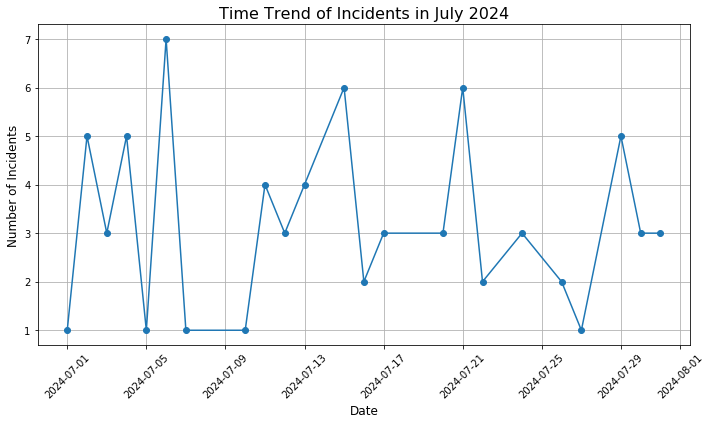

### Percentage Distribution of Injury vs. Non-Injury Incidents

- **Question**: What's the percentage distribution of incidents involving injuries?
- We'll use a `pie chart` to understand the proportion of incidents `involving injuries` versus `no injuries`.
- `plt.pie()`: This function generates a pie chart. Here are the key parameters:
  - `labels`: Labels for each slice of the pie (e.g., injury vs. non-injury).
  - `autopct='%1.1f%%'`: This formats the percentage display inside the slices.
  - `startangle=90`: Rotates the start of the pie chart to improve visual orientation.
  - `colors`: You can provide a list of colors to customize the pie chart.
- `plt.axis('equal')`: Ensures that the pie chart is drawn as a circle rather than an ellipse.

```python
# Calculate the count of incidents with injury and without injury
injury_counts = data['Injury'].value_counts()

# Create a pie chart
plt.figure(figsize=(7, 7))
plt.pie(injury_counts, labels=injury_counts.index, autopct='%1.1f%%', startangle=90, colors=['#ff9999','#66b3ff'])
plt.title("Percentage Distribution of Injury vs. Non-Injury Incidents", fontsize=16)
plt.axis('equal')  # Equal aspect ratio ensures that pie chart is drawn as a circle.
plt.show()
```

# Calculate the count of incidents with injury and without injury injury_counts = data['Injury'].value_counts() # Create a pie chart plt.figure(figsize=(7, 7)) plt.pie(injury_counts, labels=injury_counts.index, autopct='%1.1f%%', startangle=90, colors=['#ff9999','#66b3ff']) plt.title("Percentage Distribution of Injury vs. Non-Injury Incidents", fontsize=16) plt.axis('equal') # Equal aspect ratio ensures that pie chart is drawn as a circle. plt.show()

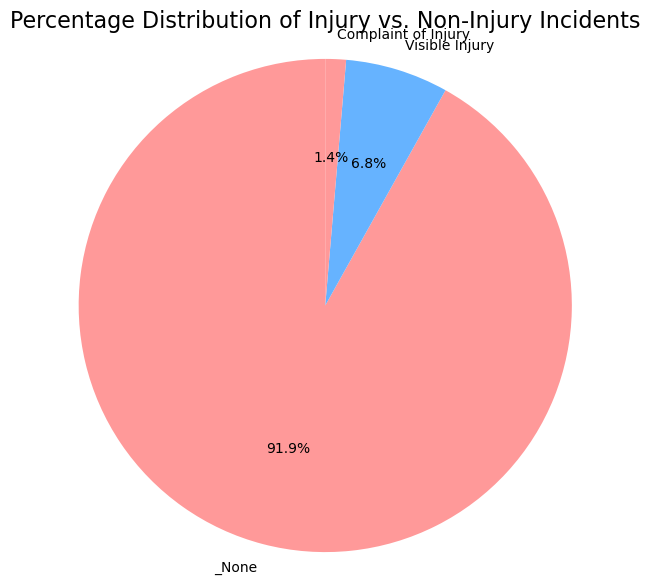

### Most Frequently Used Techniques

- **Question**: Which techniques were most frequently used in the incidents?
- We’ll create a `bar plot` to identify which techniques were most frequently employed.
- `plt.bar()`: This function creates a vertical bar plot.
  - `color='skyblue'`: Customizes the color of the bars.
  - `plt.xticks()`: Helps rotate and position the x-axis labels, ensuring they don’t overlap.
  - `plt.tight_layout()`: Ensures the plot and labels fit well within the figure area, avoiding overlap.

```python
# Count occurrences of each use-of-force technique
technique_counts = data['Implement'].value_counts()

# Create a bar plot
plt.figure(figsize=(10, 6))
plt.bar(technique_counts.index, technique_counts.values, color='skyblue')
plt.title("Most Frequently Used Techniques", fontsize=16)
plt.xlabel("Technique", fontsize=12)
plt.ylabel("Frequency", fontsize=12)
plt.xticks(rotation=45, ha='right')
plt.tight_layout()
plt.show()
```

# Count occurrences of each use-of-force technique technique_counts = data['Implement'].value_counts() # Create a bar plot plt.figure(figsize=(10, 6)) plt.bar(technique_counts.index, technique_counts.values, color='skyblue') plt.title("Most Frequently Used Techniques", fontsize=16) plt.xlabel("Technique", fontsize=12) plt.ylabel("Frequency", fontsize=12) plt.xticks(rotation=45, ha='right') plt.tight_layout() plt.show()

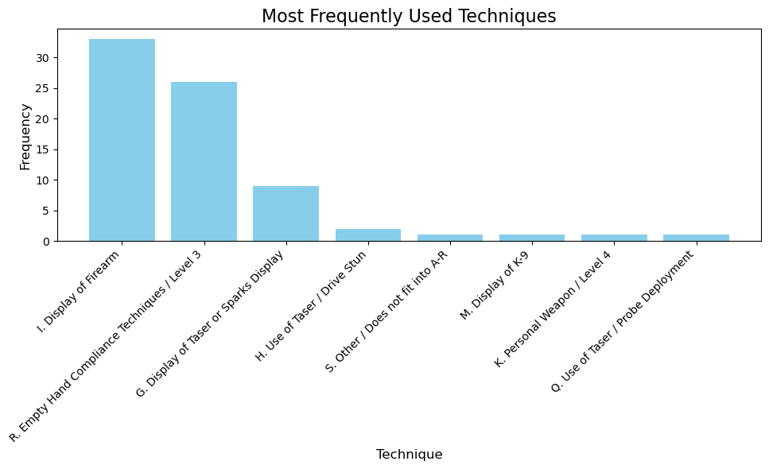

### Top Locations for Incidents

- **Question**: What are the top locations for incidents?
- Using a `horizontal bar plot`, we will examine which locations had the most incidents.
- `plt.barh()`: Creates a horizontal bar plot.
  - This is especially useful when your category labels (e.g., locations) are long and might overlap if displayed on the x-axis.
- `plt.barh(index, values)`: The index represents the labels (categories), and values are the frequencies or counts.
- `color='lightcoral'`: Customizes the bar color to improve visual appeal.

```python
# Count occurrences of incidents at each location
location_counts = data['Location'].value_counts()

# Sort the values in descending order and get the top 10 locations
location_counts = location_counts.sort_values(ascending=False).head(10)

# Reverse the order of the data
location_counts = location_counts.iloc[::-1]

# Create a horizontal bar plot
plt.figure(figsize=(10, 6))
plt.barh(location_counts.index, location_counts.values, color='lightcoral')
plt.title("Top 10 Locations for Incidents", fontsize=16)
plt.xlabel("Number of Incidents", fontsize=12)
plt.ylabel("Location", fontsize=12)

# Add annotation (text) on top of each bar
for i, value in enumerate(location_counts.values):
    plt.text(value + 0.1, i, str(value), va='center', fontweight='bold')

plt.tight_layout()
plt.show()
```

# Count occurrences of incidents at each location location_counts = data['Location'].value_counts() # Sort the values in descending order and get the top 10 locations location_counts = location_counts.sort_values(ascending=False).head(10) # Reverse the order of the data location_counts = location_counts.iloc[::-1] # Create a horizontal bar plot plt.figure(figsize=(10, 6)) plt.barh(location_counts.index, location_counts.values, color='lightcoral') plt.title("Top 10 Locations for Incidents", fontsize=16) plt.xlabel("Number of Incidents", fontsize=12) plt.ylabel("Location", fontsize=12) # Add annotation (text) on top of each bar for i, value in enumerate(location_counts.values): plt.text(value + 0.1, i, str(value), va='center', fontweight='bold') plt.tight_layout() plt.show()

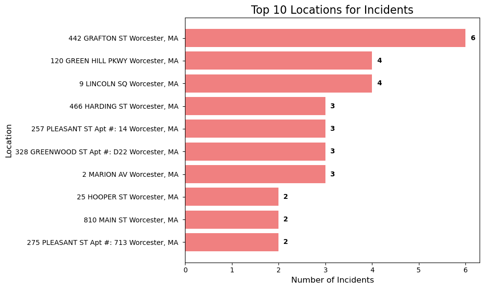

## Introduction to Seaborn

`Seaborn` is a Python data visualization library **built on top of `Matplotlib`**. It is specifically designed to make it easier to create aesthetically pleasing and informative statistical graphics.

Seaborn comes with high-level interfaces for drawing attractive and informative statistical graphics, making it a great tool for exploratory data analysis.

Key Features of Seaborn:

- **Simplified Syntax**: Seaborn allows you to create complex visualizations with just a few lines of code.
- **Integration with Pandas**: It works seamlessly with `Pandas` dataframes, allowing for easy plotting of complex datasets.
- **Built-in Statistical Functions**: `Seaborn` offers built-in functions to handle **common statistical plots** like `boxplots`, `violin plots`, and `heatmaps`.
- **Aesthetic Plotting**: Seaborn’s default settings create plots with modern, clean styles that are aesthetically pleasing without requiring additional customization.

## Comparison Between Seaborn and Matplotlib

| Feature | **Matplotlib** | **Seaborn** |
| --- | --- | --- |
| **Customization** | Highly customizable but requires more effort | Built-in themes and styles for modern designs |
| **Ease of Use** | Requires more code for complex plots | Simplified syntax for complex visualizations |
| **Default Styles** | Simple and basic | Aesthetically pleasing by default |
| **Statistical Plotting** | No built-in statistical functions | Built-in functions for statistical visualizations |
| **Integration with Pandas** | Requires conversion or manual work | Integrates directly with Pandas dataframes |
| **Plot Types** | Supports a wide range of plot types | Best suited for statistical plots |

```python
import seaborn as sns
import pandas as pd
```

import seaborn as sns import pandas as pd

### Exercise 01 lineplot: Time Trend of Incidents Over the Month of July (Seaborn)

- `sns.lineplot()`: This function simplifies the creation of a line plot with additional styling. The `marker='o'` adds markers at each data point
- **Smoother Design**: `Seaborn` automatically applies a more polished design, including better line widths and colors.

```python
import pandas as pd
import os
from pathlib import Path
```

import pandas as pd import os from pathlib import Path

```python
notebook_path = Path(os.path.abspath("__file__")).parent
os.chdir(notebook_path)
os.getcwd()
```

notebook_path = Path(os.path.abspath("__file__")).parent os.chdir(notebook_path) os.getcwd()

```
'f:\\Clark_Universiy\\Clark_Teaching\\Git_Repo\\ssj-302\\docs\\Lectures\\Week06_visualization'
```

```python
data = pd.read_csv('./Worcester_Police_Use_of_Force_Incidents_(July_2024).csv')

# Convert 'Date___Time' column to datetime format
data['Date___Time'] = pd.to_datetime(data['Date___Time'], format='%m/%d/%y %I:%M %p')

# Create a new column for the date
data['Date'] = data['Date___Time'].dt.date

# Group data by date and count incidents per day
incidents_per_day = data.groupby('Date').size()

incidents_per_day
```

data = pd.read_csv('./Worcester_Police_Use_of_Force_Incidents_(July_2024).csv') # Convert 'Date___Time' column to datetime format data['Date___Time'] = pd.to_datetime(data['Date___Time'], format='%m/%d/%y %I:%M %p') # Create a new column for the date data['Date'] = data['Date___Time'].dt.date # Group data by date and count incidents per day incidents_per_day = data.groupby('Date').size() incidents_per_day

```
Date
2024-07-01    1
2024-07-02    5
2024-07-03    3
2024-07-04    5
2024-07-05    1
2024-07-06    7
2024-07-07    1
2024-07-10    1
2024-07-11    4
2024-07-12    3
2024-07-13    4
2024-07-15    6
2024-07-16    2
2024-07-17    3
2024-07-20    3
2024-07-21    6
2024-07-22    2
2024-07-24    3
2024-07-26    2
2024-07-27    1
2024-07-29    5
2024-07-30    3
2024-07-31    3
dtype: int64
```

```python
# Create a line plot with Seaborn
```

# Create a line plot with Seaborn

## Plotly

```python
!pip install plotly
```

!pip install plotly

## Plotly Express

[Plotly Express](https://plotly.com/python/plotly-express/) is a high-level interface for creating interactive visualizations in Python. It simplifies the process of making complex, interactive plots by offering concise syntax.

```python
## Scatter plots
import plotly.express as px

df = px.data.stocks()
print(df.head(5))
fig = px.line(df, x='date', y="GOOG")
fig.show()
```

[output not shown]

## Scatter plots import plotly.express as px df = px.data.stocks() print(df.head(5)) fig = px.line(df, x='date', y="GOOG") fig.show()

```
         date      GOOG      AAPL      AMZN        FB      NFLX      MSFT
0  2018-01-01  1.000000  1.000000  1.000000  1.000000  1.000000  1.000000
1  2018-01-08  1.018172  1.011943  1.061881  0.959968  1.053526  1.015988
2  2018-01-15  1.032008  1.019771  1.053240  0.970243  1.049860  1.020524
3  2018-01-22  1.066783  0.980057  1.140676  1.016858  1.307681  1.066561
4  2018-01-29  1.008773  0.917143  1.163374  1.018357  1.273537  1.040708
```

### Exercise 02 Line plot: Time Trend of Incidents Over the Month of July (Plotly)

## Bar charts with Plotly Express

```python
data_canada = px.data.gapminder().query("country == 'Canada'")
fig = px.bar(data_canada, x='year', y='pop')
fig.show()
```

[output not shown]

data_canada = px.data.gapminder().query("country == 'Canada'") fig = px.bar(data_canada, x='year', y='pop') fig.show()

### Exercise 03 Bar chart: Time Trend of Incidents Over the Month of July (Plotly)

## Spatial Map

[Graphing Libraries](https://plotly.com/python/)

### Exercise 04: Spatial Map

https://plotly.com/python/reference/layout/geo/

[Data Source](https://data.boston.gov/dataset/treekeeper-street-trees)

[Code Demo](https://plotly.com/python/scatter-plots-on-maps/)

```python
import plotly.graph_objects as go
```

import plotly.graph_objects as go